# Prediction of Exercise Class

Justin Rice

### Executive Summary

This study was commissioned to predict the class of how a subject performed an exercise. The data used for this project was collected from a range of wireless activity wristbands. The wristbands were worn be the subjects as they performed excercies in 5 different ways. To study the data I broke the source data into a training and testing set. I experimented with 2 training models; Decision Tree and Random Forest. The decision tree performed very poorly which is likely to be caused by a lack of homogeneity in the data. We know that random forest is one of the most accurate models and it proved itself here with this data.

### Getting and Cleaning

```r
library(knitr)
library(dplyr)
library(plyr)
library(ggplot2)
library(gridExtra)
library(caret)
library(party)
#library(e1071)

set.seed(2016)

#download the data if it doesn't already exist
if(!file.exists("pml-training.csv")) {
  trainURL <- "https://d396qusza40orc.cloudfront.net/predmachlearn/pml-training.csv"
  download.file(trainURL, destfile="pml-training.csv")
}

if(!file.exists("pml-testing.csv")) {
  trainURL <- "https://d396qusza40orc.cloudfront.net/predmachlearn/pml-testing.csv"
  download.file(trainURL, destfile="pml-testing.csv")
}

#Load the data into R
  pmlVal <- read.csv("pml-testing.csv")
  pmlData <- read.csv("pml-training.csv")

#Remove all the columns that include NA values
NAcols <- colSums(is.na(pmlData)) == 0
Validcolumns <- sum(NAcols == TRUE)
pmlData <- pmlData[, NAcols]


#Remove columns that are not meaningful predictors
nzv <- nearZeroVar(pmlData, saveMetrics = T)
pmlData <- pmlData[, nzv$nzv==F]

#pmlData <- head(pmlData, 1000)
str(pmlData)
```

```
## 'data.frame':    19622 obs. of  59 variables:
##  $ X                   : int  1 2 3 4 5 6 7 8 9 10 ...
##  $ user_name           : Factor w/ 6 levels "adelmo","carlitos",..: 2 2 2 2 2 2 2 2 2 2 ...
##  $ raw_timestamp_part_1: int  1323084231 1323084231 1323084231 1323084232 1323084232 1323084232 1323084232 1323084232 1323084232 1323084232 ...
##  $ raw_timestamp_part_2: int  788290 808298 820366 120339 196328 304277 368296 440390 484323 484434 ...
##  $ cvtd_timestamp      : Factor w/ 20 levels "02/12/2011 13:32",..: 9 9 9 9 9 9 9 9 9 9 ...
##  $ num_window          : int  11 11 11 12 12 12 12 12 12 12 ...
##  $ roll_belt           : num  1.41 1.41 1.42 1.48 1.48 1.45 1.42 1.42 1.43 1.45 ...
##  $ pitch_belt          : num  8.07 8.07 8.07 8.05 8.07 8.06 8.09 8.13 8.16 8.17 ...
##  $ yaw_belt            : num  -94.4 -94.4 -94.4 -94.4 -94.4 -94.4 -94.4 -94.4 -94.4 -94.4 ...
##  $ total_accel_belt    : int  3 3 3 3 3 3 3 3 3 3 ...
##  $ gyros_belt_x        : num  0 0.02 0 0.02 0.02 0.02 0.02 0.02 0.02 0.03 ...
##  $ gyros_belt_y        : num  0 0 0 0 0.02 0 0 0 0 0 ...
##  $ gyros_belt_z        : num  -0.02 -0.02 -0.02 -0.03 -0.02 -0.02 -0.02 -0.02 -0.02 0 ...
##  $ accel_belt_x        : int  -21 -22 -20 -22 -21 -21 -22 -22 -20 -21 ...
```

[output cut: 45 more lines]

After the data was loaded, it was important to remove the NA columns as they could mislead the results. I also removed the columns that did not contribute any variance to the prediction model.

### Setup Cross-Validation

```r
partition <- createDataPartition(pmlData$classe, p=0.8, list=F)
inTrain <- pmlData[partition, ]
inTest <- pmlData[-partition, ]
i <- data.frame("Total"=c(nrow(inTrain), nrow(inTest)))
DT <- matrix(NA, nrow=2, ncol=5)
TR <- as.data.frame(table(inTrain$classe))
TE <- as.data.frame(table(inTest$classe))
DT[1, ] <- TR[,2]
DT[2, ] <- TE[,2]
g <- as.data.frame(DT)
colnames(g) <- c("A", "B", "C", "D", "E")
e<- cbind(g, i)
f <- colSums(e)
r <-  rbind(e, f)
rownames(r) <- c('Training Data','Testing Data','Total')
kable(r)
```

|  | A | B | C | D | E | Total |
| --- | --- | --- | --- | --- | --- | --- |
| Training Data | 4464 | 3038 | 2738 | 2573 | 2886 | 15699 |
| Testing Data | 1116 | 759 | 684 | 643 | 721 | 3923 |
| Total | 5580 | 3797 | 3422 | 3216 | 3607 | 19622 |

This shows the break-down of the outcome variable.

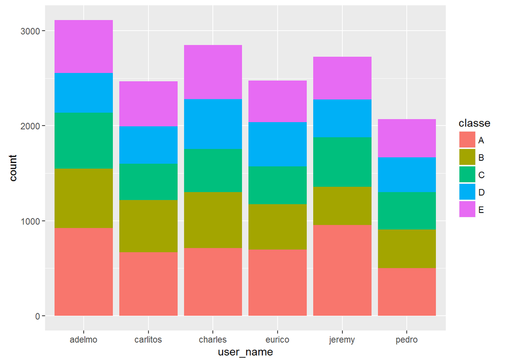

```r
qplot(user_name, data=inTrain, fill=classe)
```

### Build Decision Tree Model

```r
treeFit <- train(classe ~., method="rpart", data=inTrain)
treePred <- predict(treeFit, newdata=inTest)
treeMatrix <- confusionMatrix(inTest$classe, treePred)
treeMatrix$overall['Accuracy']
```

```
##  Accuracy
## 0.6614836
```

```r
treeMatrix$table
```

```
##           Reference
## Prediction    A    B    C    D    E
##          A 1116    0    0    0    0
##          B    1  758    0    0    0
##          C    0    0    0    0  684
##          D    0    0    0    0  643
##          E    0    0    0    0  721
```

### Random Forest

```r
ctrl <- trainControl(allowParallel = T, method="cv", number=4)
rfFit <- train(classe ~., method="rf", data=inTrain, trControl=ctrl)
rfPred <- predict(rfFit, newdata=inTest)

rfMatrix <- confusionMatrix(inTest$classe, rfPred)
rfMatrix$overall['Accuracy']
```

```
##  Accuracy
## 0.9997451
```

```r
rfMatrix$table
```

```
##           Reference
## Prediction    A    B    C    D    E
##          A 1116    0    0    0    0
##          B    1  758    0    0    0
##          C    0    0  684    0    0
##          D    0    0    0  643    0
##          E    0    0    0    0  721
```

### Out of Sample Error

```r
err <- 1-rfMatrix$overall['Accuracy']
err
```

```
##    Accuracy
## 0.000254907
```

The expected Out of Sample Error is 0.02% which is very good for prediction. Therefore we will use the random forest.

### Predict New Data

```r
pmlVal <- pmlVal[, NAcols]
pmlVal <- pmlVal[, nzv$nzv==F]
testing <- pmlVal[, 1:58]

testPred <- predict(rfFit, newdata=testing)
```